# Module 1 Homework - DAGS

ECON 526/593E

# DAGS and Causality

**Click for Submission Instructions & Data**

Prepare your answers in R Markdown. Your submission should contain the exact same headings shown below along with your text and graphs, where appropriate, addressing all questions. When you knit your R Markdown script, use the following file naming convention for the html document you generate: lastname_module_N_homework.html (replace "lastname" with your last name and "N" with the module number). Email your html document as an attachment to ajc0056@mix.wvu.edu with the subject line "ECON 593 lastname Homework Module N". You can download the data for this module here.

DAGs are important tools for visualizing causal relationships. This homework focuses on the application of dags in empirical research and the use of simple OLS regression models to illustrate how DAGs help us understand regression results.

Consider the case of professional basketball teams and players. Professional basketball teams want to maximize the number of games won in each season. In order to win a basketball game, one team must outscore its opponent. To simplify the analysis, suppose that basketball teams are interested in only two factors that affect wins: possessing the ball and scoring the ball. Players gain possession of the ball by rebounding missed shots by their team or the other team. In this simple case, assume that players accumulate only two performance statistics: points and rebounds. Teams want to maximize wins, so they will pay players who score more points a higher salary than less prolific scorers and pay players who rebound more a higher salary than players less able to rebound.

Points and rebounds are not distributed equally across players. Taller players are more likely to pull down rebounds since they are quite literally closer to the hoop than shorter players. Height is positively related to rebounds. As taller players are busy getting rebounds, shorter players realize their comparative advantage lies in scoring. Shorter players tend to move towards the opposite basket and wait for a pass from a taller player so they can score instead of trying to rebound the ball. Height is negatively related to scoring. Again, height is correlated with both rebounds (positively) and points (negatively). Height could also affect salary independent of scoring and rebounding, because of its effect on defense.

Height also improves a player's defensive ability in basketball since tall players are harder to shoot over and dribble around. Better defensive players prevent opposing players from scoring. This means professional basketball teams also value height by itself.

Suppose an econometrician (you) observe points scored per game, rebounds per game, height and salary for a sample of professional basketball players in the NBA over a season $(N = 300)$.

### Question 1

Suppose that NBA players are paid based on their on-court production, in terms of points scored and rebounds. Height could also have a direct impact on salary, alon with the indirect effect through its impact on scoring and rebounding. We are interested in estimating the causal effect of rebounds and points scored on salary in the NBA in a regression model.

Draw a DAG to visualize the relationships between the four key variables in this example: height, points scored, rebounds, and salary. The description above forms the basis for the nodes and arrows in your DAG. Note that an arrow is also called an "edge" in the jargon of DAGs. (**3 Points**)

```r
#need library "DiagrammeR"
#link here: https://donlelek.github.io/2015-03-31-dags-with-r/

library("DiagrammeR")

mermaid("
          graph LR
          H(Height)-->S(Salary)
          H-->P(Points)
          H-->R(Rebounds)
          R-->S
          P-->S
          ")
```

[interactive chart not shown]

Identify the three direct paths or *causal relationships* on your DAG.

Identify the two *backdoors* on your DAG.

Which variable is a *confounder* on your DAG? Explain what this means.

```
## Causal Relationships:
##   1) points - salary
##   2) rebounds - salary
##   3) height - salary
## Backdoors:
##   1) height - points
##   2) height - rebounds
## Height is a confounder since it affects points, rebounds and salary
```

### Question 2

This homework uses a simulated data set containing annual salary (in millions of dollars), average points scored per game, average rebounds per game, and height for 300 hypothetical NBA players for one season. These data were created just like the occupation and earnings data analyzed in *The Mixtape* chapter.

Read in the data set `nba_sim.csv`. Name the data set `nba`. It is very important to understand the structure and nature of the data, and basic relationships when working with a new data set. Summary statistics and graphical displays are two very useful tools for gaining a basic understanding of a new data set.

Generate summary statistics for the data sample. To generate these summary statistics, use the `stargazer` package (hint[^1], hint[^2]). (**3 Points**)

```r
library("stargazer")
nba <- read.csv("nba_sim.csv", stringsAsFactor = FALSE)

stargazer(nba, type = "text")
```

```
##
## =============================================================
## Statistic  N   Mean  St. Dev.  Min   Pctl(25) Pctl(75)  Max
## -------------------------------------------------------------
## salary    300 17.866  1.317   14.967  16.945   18.864  21.219
## rebounds  300 6.265   3.117   0.000   3.930    8.088   15.195
## points    300 14.273  4.518   2.357   11.030   17.571  27.332
## height    300 6.500   0.422   5.800   6.100    6.825   7.200
## -------------------------------------------------------------
```

Briefly explain what you learn about the data from these summary statistics.

## Question 3

Graphs represent another good way to explore new data sets. Histograms showing the distribution of a single variable, and scatter plots showing the unconditional relationship between pairs of variables are two common methods.

Generate distribution plots (histograms) for each variable using the `hist()` function. Use (or at least suggest to R) 10 bins for each variable except points, in which case you should use 20 bins. Make each plot a different color and make the plots part of one window pane (hint[^3]). Make sure to label all axes and use logical, nice-looking units.

Next, generate scatter plots for pairs of variables. Make scatter plots for Salary vs all other variables, and also for Points vs Rebounds. Label and color the scatter plot (hint[^4], hint[^5]) (**3 Points**)

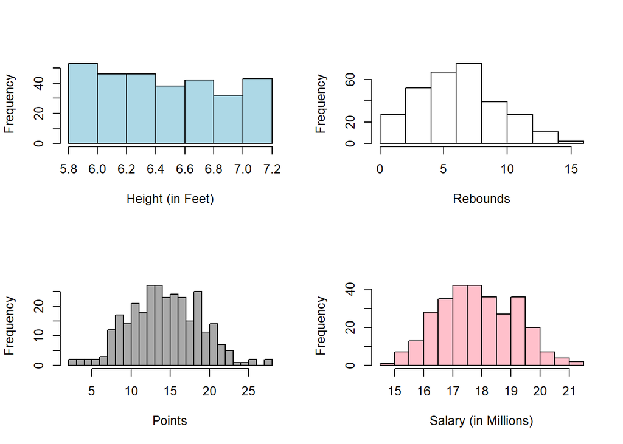

```r
par(mfrow = c(2,2))
hist(nba$height, breaks = 10, col = "light blue", main = "", xlab = "Height (in Feet)")
hist(nba$rebounds, breaks = 10, col = "white", main = "", xlab = "Rebounds")
hist(nba$points, breaks = 20, col = "dark grey", main = "", xlab = "Points")
hist(nba$salary, breaks = 10, col = "pink", main = "", xlab = "Salary (in Millions)")
par(mfrow = c(1,1))
```

Briefly discuss what these histograms reveal in terms of individual variables.

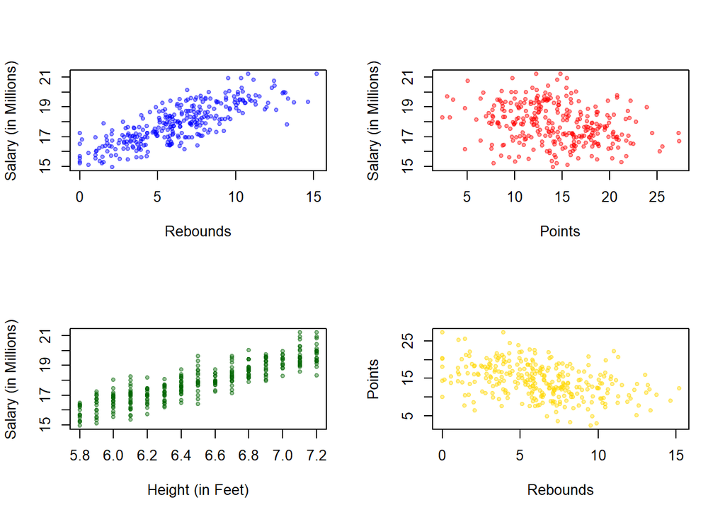

```r
library("scales")
par(mfrow = c(2,2))
plot(nba$rebounds, nba$salary, xlab = "Rebounds", ylab = "Salary (in Millions)", main = "",
     pch = 20, col = alpha("blue", .4))
plot(nba$points, nba$salary, xlab = "Points", ylab = "Salary (in Millions)", main = "",
     pch = 20, col = alpha("red", .4))
plot(nba$height, nba$salary, xlab = "Height (in Feet)", ylab = "Salary (in Millions)", main = "",
     pch = 20, col = alpha("dark green", .4))
plot(nba$rebounds, nba$points, xlab = "Rebounds", ylab = "Points", main = "",
     pch = 20, col = alpha("gold", .4))
par(mfrow = c(1,1))
```

Briefly discuss patterns in the scatter plots and clearly link these patterns back to the DAG.

### Question 4

Again, we are interested in the causal effect of scoring and rebounds on salaries in the NBA. All the causal inference methods covered in this class use regression models to estimate causal impacts. You will next estimate four separate regression models.

One simple approach is to estimate a bivariate regression model with salary as the dependent variable and points as the only explanatory variable. First, estimate a regression model that explains variation in salary using only variation in points (without rebounds or height). Call this model (1). Make sure to use literate programming conventions for variables and code when estimating this model. Use an easy to understand naming convention for regression models like `reg1, reg2, ...` or `model_a, model_b, ...`.

Next, estimate a second regression model explaining variation in salary using only variation in rebounds and no other explanatory variables. Third, estimate a multivariate regression model where salary is the dependent variable and both points and rebounds are explanatory variables. Finally, estimate a fourth regression model where salary is the dependent variable and points, rebounds and height are explanatory variables.

Display the results for all four regression models in a single table. Use `stargazer` to print out the results in a readable format (hint[^6]). (**3 Points**)

```r
reg1 <- lm(salary ~ points, data = nba)
reg2 <- lm(salary ~ rebounds, data = nba)
reg3 <- lm(salary ~ points + rebounds, data = nba)
reg4 <- lm(salary ~ points + rebounds + height, data = nba)

stargazer(reg1, reg2, reg3, reg4,
          type = "text",
          omit.stat = c("ser", "f"))
```

```
##
## ===================================================
##                       Dependent variable:
##              --------------------------------------
##                              salary
##                 (1)       (2)       (3)      (4)
## ---------------------------------------------------
## points       -0.079***             0.016   0.059***
##               (0.016)             (0.011)  (0.008)
##
## rebounds               0.337***  0.346***  0.118***
##                         (0.015)   (0.016)  (0.015)
##
## height                                     2.387***
##                                            (0.119)
##
## Constant     18.989*** 15.755*** 15.470***  0.771
##               (0.243)   (0.103)   (0.223)  (0.749)
##
## ---------------------------------------------------
## Observations    300       300       300      300
## R2             0.073     0.636     0.639    0.846
## Adjusted R2    0.070     0.635     0.636    0.845
## ===================================================
## Note:                   *p<0.1; **p<0.05; ***p<0.01
```

Interpret all these regression results using the DAG drawn above.

Start with model (1), which regresses points only on salary. What specific part of your DAG does this regression model link to? What does the parameter estimate on the points variable tell you about the monetary return to scoring points in the NBA? Does the estimated sign make sense to you? Why or why not?

Next, consider the results from model (2), which regresses rebounds only on salary. What specific part of your DAG does this regression model link to? What does the parameter estimate on the rebounds variable tell you about the monetary return to rebounding in the NBA? Does the estimated sign make sense to you? Why or why not?

Next, consider the results from model (3) which includes both points and rebounds as explanatory variables. What changes in terms of results compared to model (1) and model (2)? What part of your DAG is not reflected in all three models?

Finally, consider the results in model (4) which adds height to model (3). Discuss how the parameter estimates in model (4) change relative to those in the other three models. Explain why they change.

Explain the following statement: "model (4) closes the backdoors in the other three models".

### Question 5

The goal of this exercise is to develop causal evidence about the effect of rebounds and scoring on NBA player salaries. The previous question used regression models to estimate the relationship between these three variables. Can the regression model parameter estimates from Question 4 be interpreted as the causal impact of scoring and rebounding on NBA player salaries? Discuss your answer. hint[^7] (**3 Points**)

[^1]: Make sure to install this package with `install.packages("stargazer")`. You only have to do this **ONCE**, so do this in the console and not your Markdown file. Then, to use `stargazer`, make sure to use `library("stargazer")` within your markdown file. Then, when using the function, make sure to use the arguement `type = "text"` so it outputs as text and not unreadable LaTeX. More information [here](https://www.jakeruss.com/cheatsheets/stargazer/)
[^2]: `stargazer` does an annoying thing when you load it that generates a citation message. To stop this, enter `message = FALSE` at the beginning of your r chunk. For example `{r message = FALSE}`. To prevent figures from breaking up chunks, use `fig.show = 'hold'`
[^3]: Before you begin plotting, use `par(mfrow = c(2,2))`. Then, after generating your plots, reset this using `par(mfrow = c(1,1))`
[^4]: Sometimes plots get really busy and they become blobs. Look into the package `scales` and the function inside called `alpha`.
[^5]: Look into different plot "types" in R. [link](http://www.sthda.com/english/wiki/r-plot-pch-symbols-the-different-point-shapes-available-in-r)
[^6]: In this, pass the argument `omit.stat = c("ser", "f")` to `stargazer()` or else the output will be too wide.
[^7]: You need to think carefully about the error term in the regression model that underlies this homework to answer this question. Recall that this model is $Salary = \alpha + \beta_1 Points + \beta_2 Rebounds + \beta_3 Height + \varepsilon$. $\varepsilon$ is a mean zero unobservable random variable that captures all other factors (except scoring, rebounding, and height) that affects NBA player salaries.